# Get started with single-cell DNA copy number analyses

Rodrigo Gularte Merida gularter@mskcc.org

```r
library(gac)
```

# Getting Started

The primary container to handle the complexity of single-cell DNA data is a CNR.

The cnr is composed of a genotype (integer copy number) matrix, *X*, phenotype matrix *Y*, *expression* matrix *Ye* , a QC or metadata matrix *qc*, the *chromInfo* with chromosome-end coordinates, and a *gene.index* to map bins to specific genes. These are user provided tables. See documentation for `buildCNR` to learn how to build a CNR bundle with your data. The CNR is modeled after the expressionSet and AnnData objects from R/Bioconductor and Python, respectively. It is a lightweight and versitile framework to operate and manipulate large single-cell DNA data. The framework facilitates the use matrix operations by concurrently managing genotype and phenotype data. At the heart of the CNR bundle is the genotype *X* matrix wich hold copy number as ploidy corrected `numeric` estimations or `integer` states, with bins as rows, and cells as columns. Bins can be the direct output from Ginkgo/Varbin algorithm, or the a set of common segments from a .seg file in `matrix` form. The bin information is located on the `chromInfo` table, and the gene-to-bin mappings on the `gene.index`, which helps link the output of the segmentation to a biological context. An example on how to construt these is provided in the section **Preparing your data**.

Cell/sample phenotypes are housed in the *Y* matrix, these are sample specific and biological in nature. These are the phenotypes we wish to gain biological insights.

In a not so distant future, the posibility to acquire single-cell DNA and RNA from the same cell will become feasable at scale. To this end, a *Ye* or *exprs* matrix is included in the bundle, as for purposes of genetic analysis *gene expression* is a phenotype. If you have data of this type, it’s best to have the last/most-accurate, curated, and complete data possible for the analyses to make sense. Eg. scaled, log2-transformed, MAGIC Imputed, without duplets.

Lastly, a *qc* matrix containg metadata about each cell is required.

[figure not shown]

Figure1

Figure 1. Schematic representation of the CNR bundle and how the different components are related.

## Preparing your data

Data should be in rectancular form, preferably as a data.frame or matrix. The example data included in the package was generated as follows.

```r
## number of cells to simulate
n.cells <- 82

## set pattern
X <- as.data.frame(replicate(n = n.cells, expr = round(seq(0, 5, by = 5/4999), digits = 4)))
names(X) <- paste("cell", 0:(n.cells -1), sep = "")

## set focal
X[, 1] <- 2
X[801:840, 2:10] <- 12
X[800:843, 11:24] <- 18
X[1810:1860, 24:40] <- 22
X[3801:3881, 40:82] <- 80

## adding noisy cells
set.seed(2020)
noisy.cells <- sort(round(runif(6, min = 1, max = n.cells)))
for(i in noisy.cells) {
    X[,i] <- X[,i] + rnorm(5000)
}
```

- Phenotype in three forms, binary, categorical, and quantitive; and an additional two random variables. Must have one column named `cellID`, and must match those in the copy number matrix.

```r
Y <- data.frame(matrix(NA, nrow = n.cells, ncol = 9))
names(Y) <- c("cellID", "binary1", "binary2",
              "category1", "category2",
              "quantitative1", "quantitative2",
              "random1", "random2")
Y$cellID <- names(X)

Y$binary1 <- rep(c(0, 1), c(floor(n.cells * 0.2), ## 20% of the data
                            ceiling(n.cells * 0.8))) ## 80% of the data
Y$binary2 <- rep(c(1, 0), each = floor(n.cells/2)) ## 50:50 + NA if n.cells is an odd number

Y$category1 <- rep(LETTERS[1:3], round(c(0.33, 0.50, 0.17) * n.cells))
Y$category2 <- rep(LETTERS[26:24], round(c(0.17, 0.50, 0.33) * n.cells))

Y$quantitative1 <- c(rnorm(n = floor(n.cells * 0.2), mean = 2),
                     rnorm(n = ceiling(n.cells * 0.8), mean = 8))
Y$quantitative2 <- rev(seq(0, 20, by = 20/n.cells)[-1])
Y$quantitative2[noisy.cells] <- Y$quantitative2[noisy.cells] - abs(rnorm(1, 3))
Y$quantitative2[noisy.cells] <- Y$quantitative2[noisy.cells] + abs(rnorm(1, 3))

Y$random1 <- abs(rnorm(n.cells))
Y$random2 <- abs(rnorm(n.cells, mean = 200, sd = 300))
```

```r
qc <- data.frame(matrix(NA, nrow = n.cells, ncol = 6))
names(qc) <- c("cellID", "ReadsKept", "MedianBinCount",
               "dna.ng.ul", "sort.gate", "qc.status")

qc$cellID <- names(X)
qc$ReadsKept <- 2000000 + rnorm(n = n.cells, sd = 700000)
qc$MedianBinCount <- round(qc$ReadsKept/5000)
qc$dna.ng.ul <- 200 + rnorm(n = n.cells, sd = 70)
qc$sort.gate <- rep(c("p6", "p7"), c(floor(n.cells * 0.2),
                                     ceiling(n.cells * 0.8)))
qc$qc.status <- "PASS"
## match noisy cells to QC
qc$ReadsKept[c(noisy.cells)] <- abs(200000 + rnorm(n = 2, sd = 700000))
qc$qc.status[c(noisy.cells)] <- "FAIL"
```

- gene.index is prepared using biomart, requires bin information to map genes Bin mappings are part of the chromInfo, and user supplied. These can be downloaded from (Ginkgo)[http://qb.cshl.edu/ginkgo/?q=/T1s5zj45ztcLxoVUMxjF] or (QDNAseq)[https://bioconductor.org/packages/release/bioc/html/QDNAseq.html]. Ginkgo uses variable length bins with an equal mappability, vs QDNAseq which uses equally spaced bins with variable mappability. For this example, we’ll use the bins from (Baslan et al. 2012)[https://pubmed.ncbi.nlm.nih.gov/22555242/] and are provided in the package.

```r
suppressPackageStartupMessages({
    library(GenomicRanges)
    library(biomaRt)
    library(dplyr)
})

## load example bin data
data(chromInfo)

## get ensembl genes w/HGNC symbol
grch37 <- useMart(biomart="ENSEMBL_MART_ENSEMBL",
                  dataset = "hsapiens_gene_ensembl",
                  host="https://grch37.ensembl.org",
                  path="/biomart/martservice")

grch37.genes <- getBM(attributes = c("ensembl_gene_id", "hgnc_symbol",
                                     "chromosome_name", "start_position",
                                     "end_position", "strand", "band",
                                     "gene_biotype"),
                      mart = grch37) %>%
    filter(chromosome_name %in% c(1:22, "X", "Y")) %>%
    arrange(chromosome_name, start_position)

## set up a genomic ranges object for the gene index annotation
( grch37.genes <- GRanges(seqnames = grch37.genes$chromosome_name,
                        ranges = IRanges(start = grch37.genes$start_position,
                                         end = grch37.genes$end_position,
                                         names = grch37.genes$ensembl_gene_id),
                        ensembl_gene_id = grch37.genes$ensembl_gene_id,
                        hgnc.symbol = grch37.genes$hgnc_symbol,
                        gene.type = grch37.genes$gene_biotype) )


## set up a genomic ranges object for the genome bins
( gr.5k <- GRanges(seqnames = chromInfo$bin.chrom,
                 ranges = IRanges(start = chromInfo$bin.start,
                                  end = chromInfo$bin.end,
                                  names = 1:nrow(chromInfo))) )

## find and print the overlaps
( gr.5k.grch37.genes <- findOverlaps(gr.5k, grch37.genes,
                                     ignore.strand = TRUE) )

tail( gr.5k.grch37.genes <- as.data.frame(gr.5k.grch37.genes)[!duplicated(gr.5k.grch37.genes@to),]  )

any(duplicated(gr.5k.grch37.genes$subjectHits))

## assign binID to each gene
grch37.genes.5k <- grch37.genes[gr.5k.grch37.genes$subjectHits]
grch37.genes.5k$bin.id <- gr.5k.grch37.genes$queryHits
grch37.genes.5k

## coerce to data.frame and keep unique genes with HGNC symbols
grch37.genes.5k <- data.frame(grch37.genes.5k) %>%
    filter(hgnc.symbol != "", !duplicated(hgnc.symbol))

cnr <- buildCNR(X = X, Y= Y, qc = qc, chromInfo = chromInfo, gene.index = grch37.genes.5k)

## example for changing loss threshold in round CNR
cnr2 <- buildCNR(X = X, Y= Y, qc = qc, chromInfo = chromInfo, gene.index = grch37.genes.5k, loss = 1.5)

summaryCNR(cnr)
```

### View what data is present in the cnr

### make sure numbers of cells match in all objects

```r
data(cnr)
summaryCNR(cnr)
```

```
#> total cells: 82
#> vdj cells:   0
#> number of phenotypes:9
#> number of bins: 5000
#> number of genes in index: 33576
#> number of genes in use: 33576
#>
#> Bray-Curtis Diss.: FALSE
#> Phylo Tree: FALSE
#> Consensus Clustering: FALSE
#> K Spectral: FALSE
#> Alteration Frequencies: FALSE
#> GISTIC2: FALSE
#> VDJ Genotyping: FALSE
#> Cluster Heterogeneity: FALSE
#> Cluster Profiles: FALSE
```

I made use of [ComplexHeatmap](https://jokergoo.github.io/ComplexHeatmap-reference/book/) for this package. ComplexHeatmap is one of the most powerful visualization tools available for R. To use the richness of ComplexHeatmap, the `HeatmapCNR` function attempts to minimize the total number of presets. Please visit the ComplexHeatmap documentation to take advantage of its potential.

The `HeatmapCNR` function will create a viable plot if you are in a time constraint.

[output not shown]

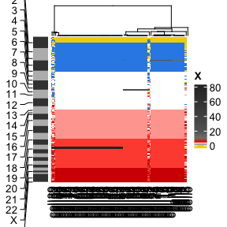

```r
## a color scale to visualize the integer copy number is provided
## visualize genome-wide
data(segCol)

HeatmapCNR(cnr, col = segCol)
```

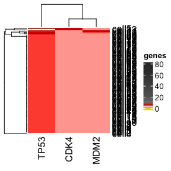

```r
## visualize genes of interest
HeatmapCNR(cnr, col = segCol, what = "genes", which.genes = c("CDK4", "MDM2", "TP53"))
```

## Working with a CNR

GAC is equiped with a couple of management functions that are prefixed with `add*`, `exclude*` and `keep*`.

On a more frequent basis you will want to remove cells that have noisy profiles.

For example to exclude cells that you have been deemed as “FAIL” b/c of low read counts you can do:

```r
## remove cells
( excl.cells <- cnr$qc$cellID[cnr$qc$qc.status == "FAIL"] )
```

```
#> [1] "cell5"  "cell11" "cell32" "cell39" "cell50" "cell52"
```

```r
cnrE <- excludeCells(cnr, excl = excl.cells)
sapply(cnrE, dim)
```

```
#> $X
#> [1] 5000   76
#>
#> $genes
#> [1]    76 33576
#>
#> $Y
#> [1] 76  9
#>
#> $qc
#> [1] 76  6
#>
#> $chromInfo
#> [1] 5000   11
#>
#> $gene.index
#> [1] 33576     9
#>
#> $cells
#> NULL
#>
#> $bulk
#> NULL
```

[output not shown]

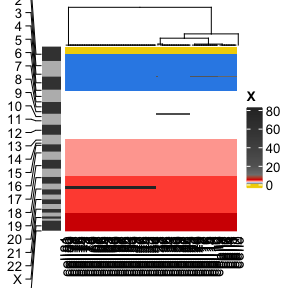

```r
HeatmapCNR(cnrE, col = segCol)
```

Conversly, if you have multiple samples or have multiple conditions and wish to use only part of the data, you can use `keepCells`

e.g.

```r
## keep cells
## offset by 1 b/c cell names are 0 based
keep.cells <- setdiff(colnames(cnr$X), paste0("cell",noisy.cells-1))

cnrK <- keepCells(cnr, keep = keep.cells)
sapply(cnrK, dim)
```

```
#> $X
#> [1] 5000   76
#>
#> $genes
#> [1]    76 33576
#>
#> $Y
#> [1] 76  9
#>
#> $qc
#> [1] 76  6
#>
#> $chromInfo
#> [1] 5000   11
#>
#> $gene.index
#> [1] 33576     9
#>
#> $cells
#> NULL
#>
#> $bulk
#> NULL
```

[output not shown]

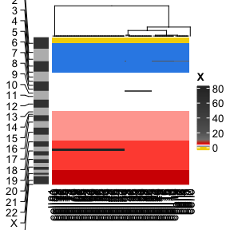

```r
HeatmapCNR(cnrK, col = segCol)
```

Lastly, if you perform a new experiment, and need to add additional cells use the `addCells`

```r
## make new cells
newX <- data.frame(cbind(rep(c(5,2), c(3000, 2000)),
                         rep(c(2,4),  c(3000, 2000))))
names(newX) <- paste0("cell", c(n.cells+1, n.cells+2))
head(newX)
```

```
#>   cell83 cell84
#> 1      5      2
#> 2      5      2
#> 3      5      2
#> 4      5      2
#> 5      5      2
#> 6      5      2
```

```r
tail(newX)
```

```
#>      cell83 cell84
#> 4995      2      4
#> 4996      2      4
#> 4997      2      4
#> 4998      2      4
#> 4999      2      4
#> 5000      2      4
```

```r
## creating new phenotypes
newY <- head(cnr$Y, n = 2)
newY$cellID <- paste0("cell", c(n.cells+1, n.cells+2))
rownames(newY) <- newY$cellID

newY[, c(6:9)] <- newY[,c(6,9)]+3
newY
```

```
#>        cellID binary1 binary2 category1 category2 quantitative1 quantitative2
#> cell83 cell83       0       1         A         Z      4.717114      46.24319
#> cell84 cell84       0       1         A         Z      3.822774     477.58834
#>         random1   random2
#> cell83 4.717114  46.24319
#> cell84 3.822774 477.58834
```

```r
## creating new QC
newQC <- head(cnr$qc, 2)
newQC$cellID <- paste0("cell", c(n.cells+1, n.cells+2))
rownames(newQC) <- newQC$cellID
newQC$qc.status <- "FAIL"

newQC[,2:4] <- newQC[,2:4] + 2
newQC
```

```
#>        cellID ReadsKept MedianBinCount dna.ng.ul sort.gate qc.status
#> cell83 cell83   1404095            283  126.8404        p6      FAIL
#> cell84 cell84   2201650            442  206.7633        p6      FAIL
```

```r
## add cells
cnrA <- addCells(cnr, newX = newX, newY = newY, newqc = newQC)
sapply(cnrA, dim)
```

```
#> $X
#> [1] 5000   84
#>
#> $genes
#> [1]    84 33576
#>
#> $Y
#> [1] 84  9
#>
#> $qc
#> [1] 84  6
#>
#> $exprs
#> NULL
#>
#> $chromInfo
#> [1] 5000   11
#>
#> $gene.index
#> [1] 33576     9
#>
#> $cells
#> NULL
#>
#> $bulk
#> NULL
```

[output not shown]

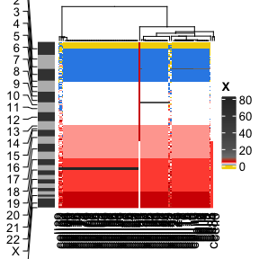

```r
HeatmapCNR(cnrA, col = segCol)
```

For developers, if you run an algorithm to estimate genomic complexity or another parameter, you can add these to the Y matrix using `addPheno`

```r
## addPheno
rand3 <- data.frame(cellID = cnr$Y$cellID, rand3 = rnorm(nrow(cnr$Y), mean = 2, sd = 1))

cnr <- addPheno(cnr, df = rand3)
sapply(cnr, dim)
```

```
#> $X
#> [1] 5000   82
#>
#> $genes
#> [1]    82 33576
#>
#> $Y
#> [1] 82 10
#>
#> $qc
#> [1] 82  6
#>
#> $chromInfo
#> [1] 5000   11
#>
#> $gene.index
#> [1] 33576     9
#>
#> $cells
#> NULL
#>
#> $bulk
#> NULL
```

```r
head(cnr$Y)
```

```
#>       cellID binary1 binary2 category1 category2 quantitative1 quantitative2
#> cell0  cell0       0       1         A         Z     1.7171139      20.00000
#> cell1  cell1       0       1         A         Z     0.8227738      19.75610
#> cell2  cell2       0       1         A         Z     1.7408635      19.51220
#> cell3  cell3       0       1         A         Z     2.5968019      19.26829
#> cell4  cell4       0       1         A         Z     1.1457773      19.02439
#> cell5  cell5       0       1         A         Z     2.5028455      18.00355
#>          random1   random2    rand3
#> cell0 0.15140097  43.24319 2.214100
#> cell1 2.07700968 474.58834 2.730811
#> cell2 0.21947875  13.59305 1.659938
#> cell3 0.55533083 236.18754 2.627665
#> cell4 0.02579636 524.62508 3.248045
#> cell5 0.40897980 184.27332 1.534600
```

Similarly, if you run a qc metric such as Median Absolute Pairwise Deviance (MAPD) which is used to estimate how noisy the profiles are. This estimate should be computed on the non-segmented bin estimates (this is not the right input for GAC as it requires you provided it segmented results). See documentation for [Ginkgo/Varbin](https://github.com/robertaboukhalil/ginkgo), MUMdex(http://mumdex.com), HMMcopy(https://bioconductor.org/packages/release/bioc/html/HMMcopy.html), or SCOPE(https://github.com/rujinwang/SCOPE) for details on how to perform the upstream analysis.

To add QC metrix use the `addQC`

```r
## add QC
mapdX <- data.frame(t(apply(cnr$X, 2, mapd)))
mapdX <- data.frame(cellID = rownames(mapdX), mapdX)

cnr <- addQC(cnr, df = mapdX)

head(cnr$qc)
```

```
#>        cellID   ReadsKept MedianBinCount dna.ng.ul sort.gate qc.status mapd
#> cell0   cell0 1404092.834            281  124.8404        p6      PASS    0
#> cell1   cell1 2201647.594            440  204.7633        p6      PASS    0
#> cell10 cell10   10680.104              2  190.7116        p6      PASS    0
#> cell11 cell11    6509.721            331  201.7667        p6      FAIL    1
#> cell12 cell12 2177831.212            436  177.6528        p6      PASS    0
#> cell13 cell13 1580168.507            316  160.2726        p6      PASS    0
#>          mapd.sd    mapd.cv
#> cell0  0.0000000        NaN
#> cell1  0.2222399 41.1473131
#> cell10 0.3414466 43.7664504
#> cell11 0.9218763  0.9020277
#> cell12 0.3414466 43.7664504
#> cell13 0.3414466 43.7664504
```

Lastly, the goal of this tool is to facilitate the genetic, and statistical analysis of single-cell copy number data. Most analysis will be carried out at the bin level. Even if you aim to work with a single gene, the bin is the smallest independent unit for segmented data. To add, for example, p-values to see which bins are linked to your phenotype the helper function is `addInfo`.

```r
## addInfo
fakePval <- data.frame(fakePval = runif(5000))

cnr <- addInfo(cnr, df = fakePval)

head(cnr$chromInfo)
```

```
#>   bin.chrom bin.start bin.start.abspos bin.end bin.length mappable.positions
#> 1         1         0                0 1311584    1311584             498370
#> 2         1   1311584          1311584 1988508     676924             498370
#> 3         1   1988508          1988508 2529293     540785             498371
#> 4         1   2529293          2529293 3144678     615385             498370
#> 5         1   3144678          3144678 3664503     519825             498370
#> 6         1   3664503          3664503 4369116     704613             498371
#>   gc.content chrom.numeric chrom chrompos  abspos  fakePval
#> 1  0.5078778             1     1        0       0 0.9396330
#> 2  0.5485328             1     1  1311584 1311584 0.8582612
#> 3  0.5919894             1     1  1988508 1988508 0.2922288
#> 4  0.5707651             1     1  2529293 2529293 0.3249087
#> 5  0.5861146             1     1  3144678 3144678 0.3580525
#> 6  0.4937208             1     1  3664503 3664503 0.9149663
```

## Clonal decomposition of cell populations based on copy number

Two methods are implemented: Heriarchical clustering, and Consensus Clustering

### Heirarchical Clustering

```r
cnr <- phyloCNR(cnr, root.cell = "cell0")
cnr <- setBrayClusters(cnr)
```

```
#> tree.height not set, using minum intersect point of 0.19 as tree.height
```

```r
table(cnr$Y$BrayC)
```

```
#>
#> C1 C2 C3 C4 C5
#>  1 21  1 16 43
```

pInternally, the operations to select the intersect are:

```r
( mopc <- optClust(cnr, seq(0, 0.2, by = 0.005)) )

plotCL(mopc)

## select a different tree height
minimum.intersect(mopc)
sc.tree.height <- 0.06

## to overwrite the tree.height
cnr <- cnr
cnr$Y <- cnr$Y[, -c(grep("BrayC", names(cnr$Y)))]

cnr <- setBrayClusters(cnr, tree.height = sc.tree.height)
```

#### Single-cell dendrogram with tree height for cluster membership

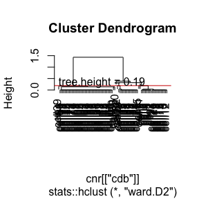

```r
plot(cnr[["hcdb"]])
abline(h = cnr$tree.height, col = "#D40000")
text(1, y = cnr$tree.height,
     labels = paste("tree.height =", cnr$tree.height),
     adj = c(0, 0))
```

#### Other tree types from package ape using the `phylo` class

```r
cnr[["phylo"]]
```

```
#>
#> Phylogenetic tree with 82 tips and 81 internal nodes.
#>
#> Tip labels:
#>   cell0, cell1, cell2, cell3, cell4, cell5, ...
#>
#> Rooted; includes branch lengths.
```

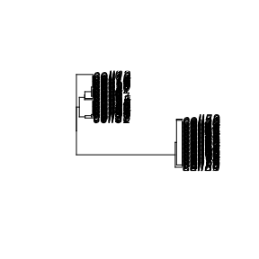

```r
plot(cnr[["phylo"]])
```

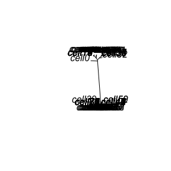

```r
plot(cnr[["phylo"]], type = 'u')
```

## Consensus clustering

In addition, we implemented [ConsensusClusterPlus](https://bioconductor.org/packages/release/bioc/html/ConsensusClusterPlus.html) using the function `run_consensus_clustering` directly on the CNR. Optimum number of clusters is based on the maximum number of stable clusters ([Meyer et al. 2013](https://arxiv.org/abs/1408.0967)). Stable Cluster membership is saved to the phenotype table `Y` as `ConsensusC`. K parameter (kCC) and number of stable clusters (sK) are saved into `cnr[["optK"]]`. The table of kCC, and kS is saved as `cnr[["kStats"]]`.

```r
data(ccClustCol)
cnr <- run_consensus_clustering(cnr, maxK = 20)
```

[output not shown]

[output cut: 3949 more lines]

[output not shown]

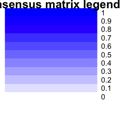

```
#> consensus  3
#> clustered
```

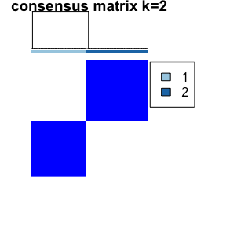

```
#> consensus  4
#> clustered
```

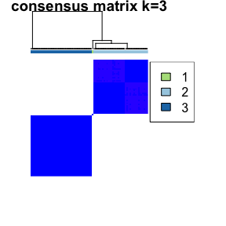

```
#> consensus  5
#> clustered
```

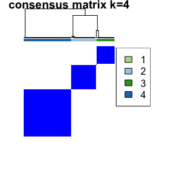

```
#> consensus  6
#> clustered
```

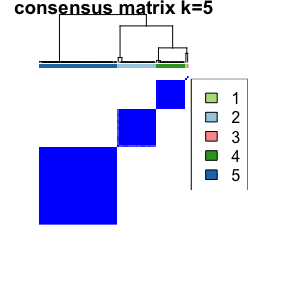

```
#> consensus  7
#> clustered
```

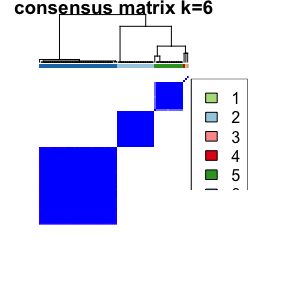

```
#> consensus  8
#> clustered
```

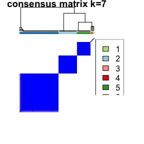

```
#> consensus  9
#> clustered
```

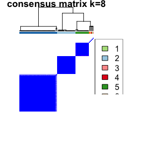

```
#> consensus  10
#> clustered
```

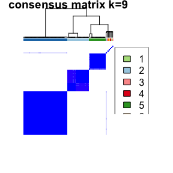

```
#> consensus  11
#> clustered
```

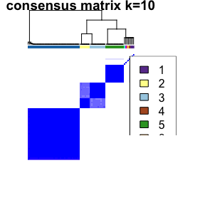

```
#> consensus  12
#> clustered
```

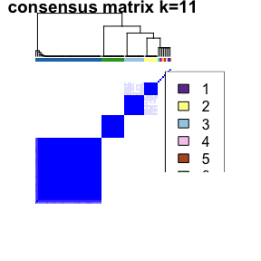

```
#> consensus  13
#> clustered
```

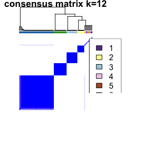

```
#> consensus  14
#> clustered
```

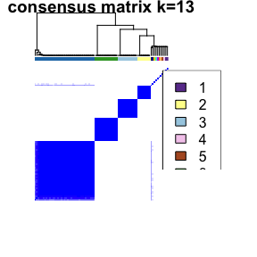

```
#> consensus  15
#> clustered
```

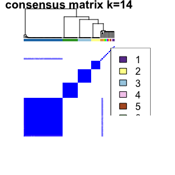

```
#> consensus  16
#> clustered
```

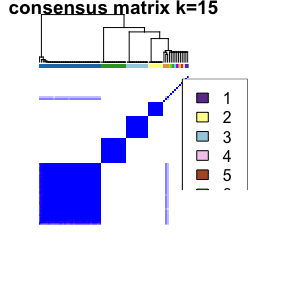

```
#> consensus  17
#> clustered
```

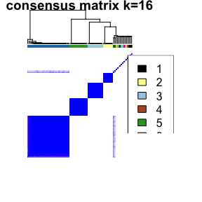

```
#> consensus  18
#> clustered
```

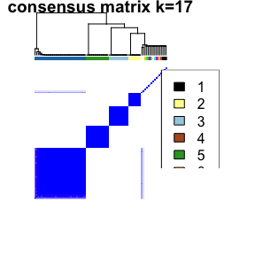

```
#> consensus  19
#> clustered
```

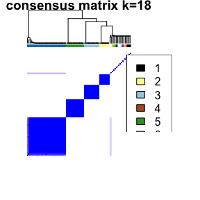

```
#> consensus  20
#> clustered
```

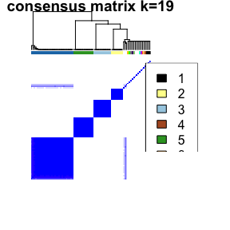

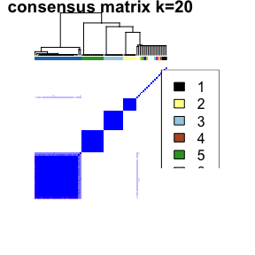

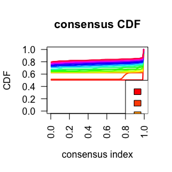

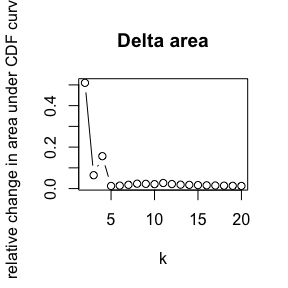

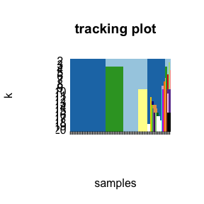

```r
cnr <- doKSpectral(cnr)
```

```
#> kCC = 2...
#> kCC = 3...
#> kCC = 4...
#> kCC = 5...
#> kCC = 6...
#> kCC = 7...
#> kCC = 8...
#> kCC = 9...
#> kCC = 10...
#> kCC = 11...
#> kCC = 12...
#> kCC = 13...
#> kCC = 14...
#> kCC = 15...
#> kCC = 16...
```

```r
cnr$kStats
```

```
#> # A tibble: 15 × 5
#>        k dLambdaMax  kMax numLambda1   kCC
#>    <dbl>      <dbl> <int>      <int> <int>
#>  1     1      1.00      2          2     2
#>  2     1      0.885     3          3     3
#>  3     1      0.979     4          4     4
#>  4     1      0.936     5          5     5
#>  5     1      0.868     6          6     6
#>  6     1      0.907     7          7     7
#>  7     1      0.845     8          8     8
#>  8     2      0.625     9          8     9
#>  9     1      0.424    10         10    10
#> 10     2      0.746    12         11    11
#> 11     1      0.541    12         12    12
#> 12     1      0.440    13         13    13
#> 13     2      0.448    15         14    14
#> 14     2      0.435    16         15    15
#> 15     2      0.442    17         16    16
```

```r
cnr$optK
```

```
#> kCC  sK
#>  11   2
```

```r
cnr <- setKcc(cnr)
```

```
#> Using recommended kCC = 11 by kSpectral
```

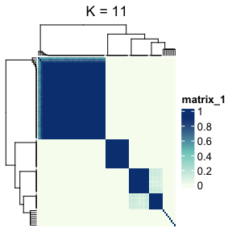

```r
plot_ccp(cnr, k = cnr$kCC, col = ccClustCol)
```

[output not shown]

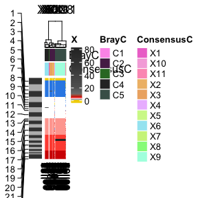

```r
HeatmapCNR(cnr, col = segCol,
           column_split = cnr$Y$ConsensusC,
           column_gap = unit(0, "mm"),
           top_annotation =
               HeatmapAnnotation(df = cnr$Y[, c("BrayC", "ConsensusC")]))
```

## Cluster heterogeneity

Sample heterogeneity based on clustering can be estimated using `cluster_heterogeneity`. The function returns a table with the same name containing the counts of each cluster, frequency, and other stats. Furthermore, it returns a vector in the phenotype table `Y` named `final_cluster`. There is no default cluster_column to use, one must choose either BrayC, ConsensusC, or if clustering was done outside GAC, these clusters can be imported to `Y` to be used here.

```r
cnr <- cluster_heterogeneity(cnr, cluster_column = "ConsensusC")

cnr$cluster_heterogeneity
```

```
#>     n.cells overall.fq n.regions sH spatial.extent cc      freqs
#> X1       82 0.02439024         1 NA             NA  2 0.02439024
#> X10      82 0.01219512         1 NA             NA  1 0.01219512
#> X11      82 0.01219512         1 NA             NA  1 0.01219512
#> X2       82 0.09756098         1 NA             NA  8 0.09756098
#> X3       82 0.14634146         1 NA             NA 12 0.14634146
#> X4       82 0.01219512         1 NA             NA  1 0.01219512
#> X5       82 0.01219512         1 NA             NA  1 0.01219512
#> X6       82 0.17073171         1 NA             NA 14 0.17073171
#> X7       82 0.01219512         1 NA             NA  1 0.01219512
#> X8       82 0.01219512         1 NA             NA  1 0.01219512
#> X9       82 0.48780488         1 NA             NA 40 0.48780488
```

## Cluster Summary Profiles

The function `get_cluster_profiles` is used to summarize the genetic profile of each cluster. Cluster summary profiles are saved in `cnr[["DDRC.df"]]`.

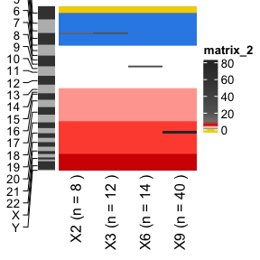

```r
cnr <- get_cluster_profiles(cnr)

chrAnnoLeft <- create_chromosome_annotation(cnr, side = "left")

Heatmap(cnr$DDRC.df, col = segCol, cluster_rows = FALSE, cluster_columns = FALSE,
        column_labels = paste(names(cnr$uclust), "(n =", cnr$uclust, ")" ),
        left_annotation = chrAnnoLeft)
```

## Phylogenetic analysis of clones

The function `phyloDDRC` was created to perform a phylogenetic analysis of clones. First a pairwise Bray-Curtis disimilarity, then the phylogeny is constructed using Neighbourhood Joining, finally the tree is rooted if a `root.clone` is provided.

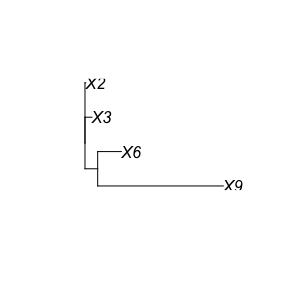

```r
cnr <- phyloDDRC(cnr, root.clone = "X2")

plot(cnr$DDRC.nj)
```

## VDJ genotyping

To asses weather T-cells or B-cells are present in the cell populations, the function genotype_vdj will classify cells containing VDJ deletions into T-cells, B-cells, or vdj.unspecified. A visualization function is also provided.

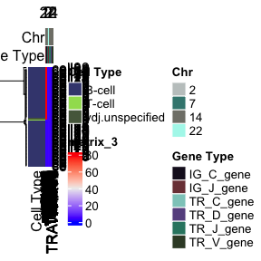

```r
cnr <- genotype_vdj(cnr)

vdjHeatmap(cnr)
```

## Example of a complete analysis pipeline

```r
library(tidyverse)
data(cnr)

noisy.cells <- cnr$qc$cellID[cnr$qc$qc.status == "FAIL"]

cnr <- cnr %>%
    excludeCells(excl = noisy.cells) %>%
    phyloCNR(root.cell = "cell0") %>%
    setBrayClusters() %>%
    run_consensus_clustering(iters = 20, maxK = 40) %>%
    doKSpectral() %>%
    setKcc() %>%
    cluster_heterogeneity(by = "category1",
                          cluster_column = "ConsensusC") %>%
    get_cluster_profiles() %>%
    get_alteration_frequencies() %>%
    genotype_vdj() %>%
    phyloDDRC(root.clone = "X2")
```

[output not shown]

[output cut: 750 more lines]

[output not shown]

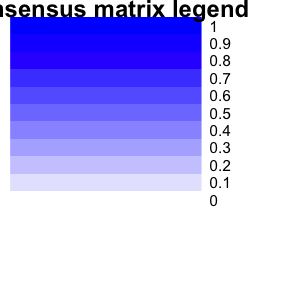

```
#> consensus  3
#> clustered
```

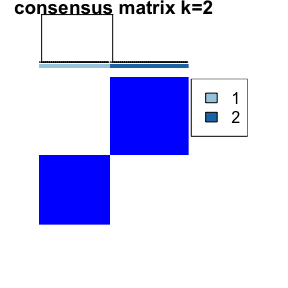

```
#> consensus  4
#> clustered
```

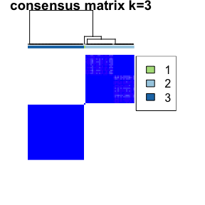

```
#> consensus  5
#> clustered
```

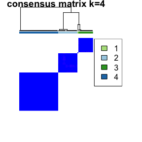

```
#> consensus  6
#> clustered
```

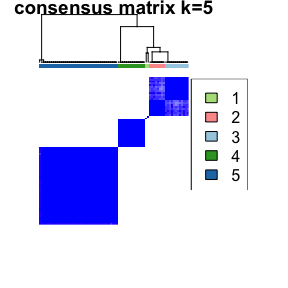

```
#> consensus  7
#> clustered
```

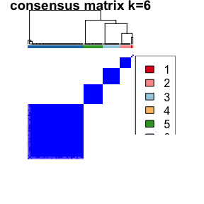

```
#> consensus  8
#> clustered
```

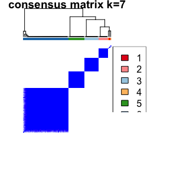

```
#> consensus  9
#> clustered
```

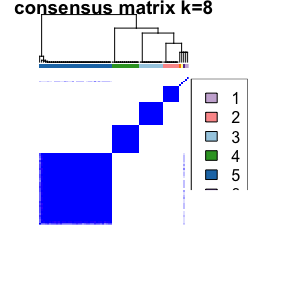

```
#> consensus  10
#> clustered
```

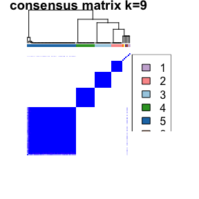

```
#> consensus  11
#> clustered
```

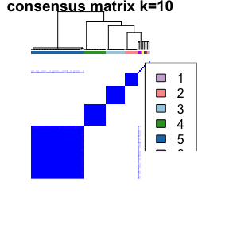

```
#> consensus  12
#> clustered
```

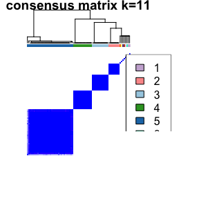

```
#> consensus  13
#> clustered
```

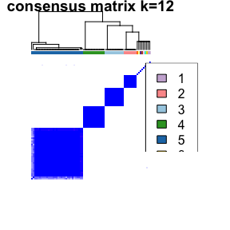

```
#> consensus  14
#> clustered
```

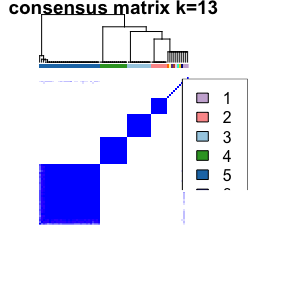

```
#> consensus  15
#> clustered
```

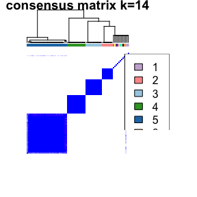

```
#> consensus  16
#> clustered
```

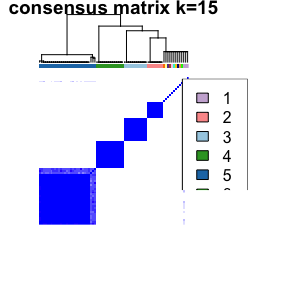

```
#> consensus  17
#> clustered
```

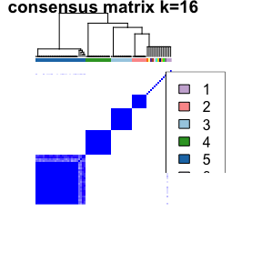

```
#> consensus  18
#> clustered
```

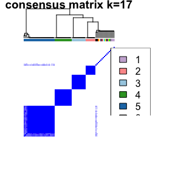

```
#> consensus  19
#> clustered
```

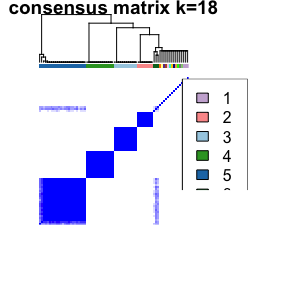

```
#> consensus  20
#> clustered
```

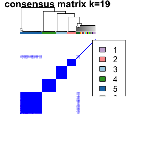

```
#> consensus  21
#> clustered
```

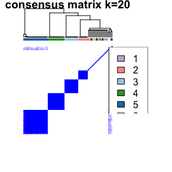

```
#> consensus  22
#> clustered
```

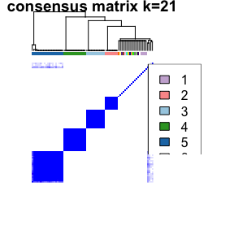

```
#> consensus  23
#> clustered
```